# Activity 3: Introduction to Inference and Hypothesis Testing

So, if we bring this back to the context of the sample mean versus the population mean, there are just a few more key pieces of info that we need. First, it turns out that, for a standard normal distribution 95% of the data fall within 1.96 standard deviations of the mean, which looks like this graphically.

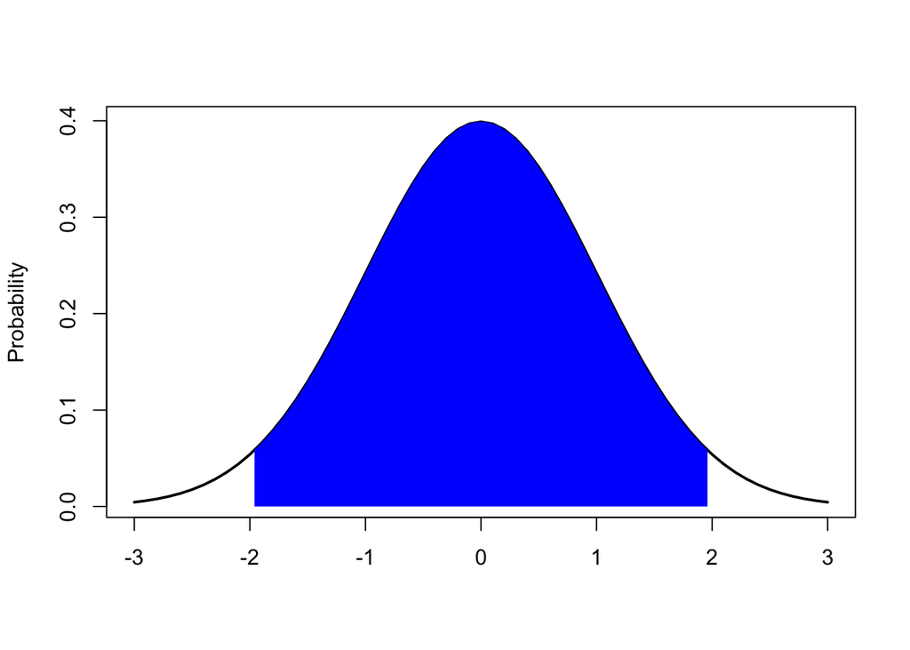

So, we can calculate the 95% confidence interval as 1.96 times the standard deviation divided by the square root of the sample size.

```r
(1.96*s)/sqrt(n)
```

```
## [1] 2.163986
```

What does this number mean to us?

Note that the z-value applies only when the sample size (*n*) is sufficiently large, and in the case of small samples the *t-distribution* is used. A sample size of 30 is typically sufficient.

For example, if we define the mean, standard deviation, and sample size of thaw depth data from the *BFG* site as *x2*, *s2*, and *n2*

```r
x-x2
```

```
## [1] 2.75719
```

```r
1.96*sqrt(s^2/n+s2^2/n2)
```

```
## [1] 3.724203
```

How do we interpret these values?

Note that we can also calculate confidence intervals for proportional data using a similar approach. But in the interest of time we will not step through that here.

## 2. Hypothesis Testing

Now, using these assumptions related to the normal distribution of sample data, we can test hypotheses. We’ll continue on using our thaw depth data as an example and begin by performing a one-sample z-test of the mean. The first step is to develop a *null hypothesis*.

For example, the null case might be that the true mean thaw depth at WWS is 45, which is long term mean for similar ecosystems in the region.

### *H*<sub>0</sub>:$\mu$=45

Null hypotheses can be viewed as a default, in that failing to reject it indicates that our sample is representative of the regional average.

Next, we establish an alternative hypothesis. Alternative hypotheses can be one-sided (e.g. the true mean thaw depth is greater than 45cm),

### *H*<sub>A</sub>: $\mu$>45

or two-sided (e.g. the true mean thaw depth is not equal to 45cm).

### *H*<sub>A</sub>: $\mu\neq$ 45

Now we can calculate our *z-score* as follows:

### z = $\frac{x-\mu}{s/\sqrt{n}}$

or

```r
((x-45)/(s/sqrt(n)))
```

```
## [1] 1.246508
```

Using the z-score Table, what is our *p-value*?

What does this mean, and how do we interpret this result?

This type of testing can be useful if you are interested in knowing whether your sample is representative of, or deviates from, a larger population. Note too that as with our previous examples, the *t-score* can be used in cases with a small sample size, and there are also variants of this analysis that can be used with proportional data.

Before we move on, it is important to take a moment to consider *p-values*. Traditionally, *p-values* have been used to determine whether or not a result is statistically significant. This has come to be seen as problematic for several reasons, including the arbitrary selection of $\alpha$ values, and the potential for misinterpretation of results. As an alternative to this, some scientists now simply report *p-values*, without definitively rejecting or failing to reject hypotheses, and let the scientific community interpret the results and determine their importance.

Now that we’ve considered that, let’s look at one final example; testing for differences in means. Here we will use a *t-test*, which you may be familiar with and is often referred to as the Student’s t-test. As you’ve likely noted from the many hours spent pouring through the text book,our math is becoming slightly more complex. Luckily for us, there happens to be the `t.test` function for us to use in R.

Let’s give it a whirl.

```r
t.test(thaw$td[thaw$site=="wws"],
       thaw$td[thaw$site=="bfg"],
       var.equal = T,
       conf.level = 0.01)
```

```
##
##  Two Sample t-test
##
## data:  thaw$td[thaw$site == "wws"] and thaw$td[thaw$site == "bfg"]
## t = 1.4855, df = 162, p-value = 0.1393
## alternative hypothesis: true difference in means is not equal to 0
## 1 percent confidence interval:
##  2.733891 2.780489
## sample estimates:
## mean of x mean of y
##  46.37624  43.61905
```

```r
# or we can specify our variables a little differently,
# and change our confidence interval
# and our assumption about the variance
t.test(td~site,
       data = thaw,
       var.equal = F,
       conf.level = 0.05)
```

```
##
##  Welch Two Sample t-test
##
## data:  td by site
## t = -1.4511, df = 121.71, p-value = 0.1493
## alternative hypothesis: true difference in means is not equal to 0
## 5 percent confidence interval:
##  -2.876585 -2.637795
## sample estimates:
## mean in group bfg mean in group wws
##          43.61905          46.37624
```

```r
# we can even use this for one sample testing
t.test(thaw$td[thaw$site=="wws"],
       mu=45,
       conf.level = 0.01)
```

```
##
##  One Sample t-test
##
## data:  thaw$td[thaw$site == "wws"]
## t = 1.2465, df = 100, p-value = 0.2155
## alternative hypothesis: true mean is not equal to 45
## 1 percent confidence interval:
##  46.36237 46.39011
## sample estimates:
## mean of x
##  46.37624
```

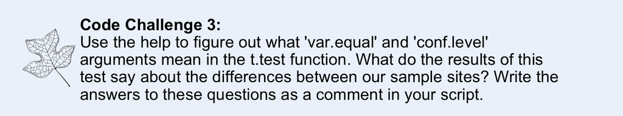

```r
# perform a t-test assuming equal variance
t1 <- t.test(td~site,
          data = thaw,
          var.equal = T,
          conf.level = 0.05)

# perform an Analysis of Variace with the same data
t2 <- aov(td~site,
          data = thaw)
```

Examine the t-test results.

```r
#examine the results
t1
```

```
##
##  Two Sample t-test
##
## data:  td by site
## t = -1.4855, df = 162, p-value = 0.1393
## alternative hypothesis: true difference in means is not equal to 0
## 5 percent confidence interval:
##  -2.873757 -2.640623
## sample estimates:
## mean in group bfg mean in group wws
##          43.61905          46.37624
```

Examine the ANOVA results. Note we have to use the *summary* function to see the results, and the *TukeyHSD* function to look at differences between means.

```r
# we have to use the summary function for the ANOVA results
summary(t2)
```

```
##              Df Sum Sq Mean Sq F value Pr(>F)
## site          1    295   294.9   2.207  0.139
## Residuals   162  21653   133.7
```

```r
# to look a differences between means
# and related confidence intervals
# use the TukeyHSD function
TukeyHSD(t2,
         conf.level = 0.05)
```

```
##   Tukey multiple comparisons of means
##     5% family-wise confidence level
##
## Fit: aov(formula = td ~ site, data = thaw)
##
## $site
##            diff      lwr      upr     p adj
## wws-bfg 2.75719 2.640623 2.873757 0.1393494
```

How do these results compare to one another? Do both tests reach the same conclusion? What are the noticeable differences between the outputs?

## Homework 4

The following questions will build on some of your code from Homework 2. You should create a new script for this assignment names *hw4_script.R* and save this in your GEOG250 project. You should copy relevant code from HW2 to get started, and be sure to correct any mistakes you made. Submit a Word/PDF document with your written answers, and your R script to Moodle Before class on Tuesday Oct 27th.

In the text book, the author discusses an example ANOVA that tests whether there are significant differences in precipitation from day to day in New York City. The underlying hypothesis is that air pollution associated with industrial emissions could generate more cloud condensation nuclei, which in turn could lead to more precipitation. The results indicate greater precipitation in Fridays on Saturday that could possible be explained by a time lag in precipitation.

Most of the climate data we have been working with come from rural locations that do not likely experience diurnal variation in air pollutants throughout the week. To understand the problem better we will analyze day to day variation in precipitation for our data set to see if there are any patterns.

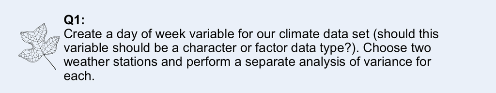

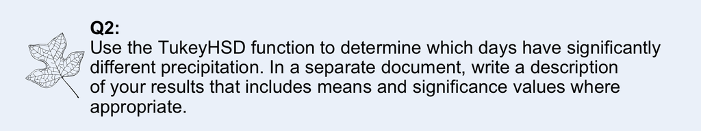

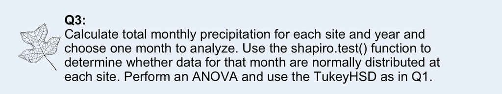

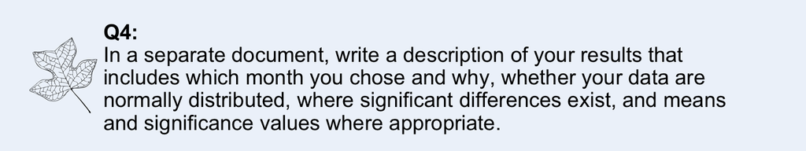